# 3FGL Source Classification vs. 4FGL Discovery

### Data Source

“FGL4.rData” are downloaded from Fermi LAT data products. “FGL4_tidy_for_FGL3.rData” are processed 4FGL data catalog. (https://fermi.gsfc.nasa.gov/ssc/data/access/ )

“FGL3_results.rData” and related scripts are associated with the following publication:

“Classification and Ranking of Fermi LAT Gamma-ray Sources from the 3FGL Catalog Using Machine Learning Techniques”,

Saz Parkinson, P. M. (HKU/LSR, SCIPP), Xu, H. (HKU), Yu, P. L. H. (HKU), Salvetti, D. (INAF-Milan), Marelli, M. (INAF-Milan), and Falcone, A. D. (Penn State), The Astrophysical Journal, 2016, in press (http://arxiv.org/abs/1602.00385)

```r
library(dplyr)
library(devtools)
library(ggplot2)

load("fermicatsR/data/FGL4.rData")
load("fermicatsR/FGL3_results.rdata")
load("fermicatsR/FGL4_tidy_for_FGL3.rData")
```

### Check 3FGL classification results based on 4FGL new discovery

Out of 3033 3FGL sources, 469 are missing in 4FGL for various reasons.

Important variables:

- Variability Index
- Curvature
- Hardneww Ratio [Ackerman et al. 2012]:

$hr_{ij} = \frac{EnergyFlux_j - EnergyFlux_i} {EnergyFlux_j + EnergyFlux_i}$, where

$EnergyFlux_{i}$ is log photon flux in energy bands. hr = -1 for very soft source (high $EnergyFlux_j = 0$), +1 for very hard source (low $EnergyFlux_i = 0$)

In plot variabiltiy vs. curvature, pulsars ($\bigtriangleup$) in bottom-right corner, with curved spectrum and low variability. Misclassifications (red) are low variability sources

#### 1. 3FGL Unassociated sources with significance > 10

```r
FGL3_unassoc_signif_res <- FGL3_results %>%
        filter(CLASS1 == "") %>%
        filter(Signif > 10) %>%       #>10: 149 obs
        filter(LR_Pred==RF_Pred) %>%
        # filter(LR_Pred=="PSR") %>%
        arrange(desc(Signif))

FGL3_unassoc_res_FGL4 <- inner_join(FGL3_unassoc_signif_res, FGL4_tidy_for_FGL3,
                                    by = c("Source_Name" = "FGL3_Source_name")) %>% #>10: 108
                        filter (CLASS1.y != "")  #>10: 47

FGL3_accuracy_pred <- mutate(FGL3_unassoc_res_FGL4,
       accurate=(FGL3_unassoc_res_FGL4$LR_Pred==FGL3_unassoc_res_FGL4$class))

table(FGL3_accuracy_pred$class,FGL3_accuracy_pred$accurate)
```

```
##
##         FALSE TRUE
##   AGN       5   17
##   PSR       1   19
##   Other     5    0
```

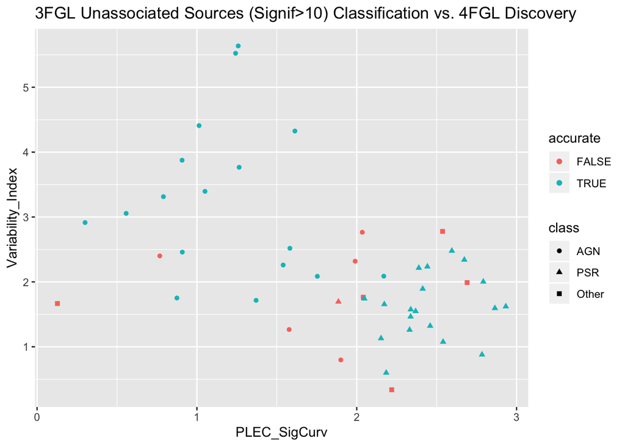

```r
ggplot(FGL3_accuracy_pred, aes(x=PLEC_SigCurv, y=Variability_Index, shape=class, color= accurate)) +
        geom_point() +
        labs(title="3FGL Unassociated Sources (Signif>10) Classification vs. 4FGL Discovery",
             x="PLEC_SigCurv", y = "Variability_Index")
```

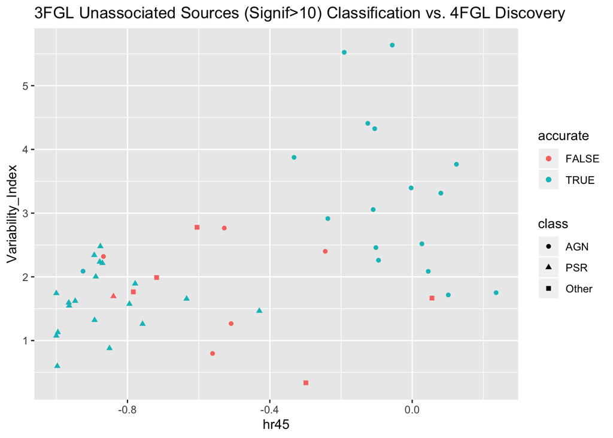

```r
ggplot(FGL3_accuracy_pred, aes(x=hr45, y=Variability_Index, shape=class, color= accurate)) +
        geom_point() +
        labs(title="3FGL Unassociated Sources (Signif>10) Classification vs. 4FGL Discovery",
             x="hr45", y = "Variability_Index")
```

#### 2. 3FGL Unassociated sources with significance > 4 (Whole Catalog)

```r
FGL3_unassoc_results <- FGL3_results %>%
        filter(CLASS1 == "") %>%
        filter(Signif > 4) %>%      #4: 921 obs
        filter(LR_Pred==RF_Pred) %>%
        # filter(LR_Pred=="PSR") %>%
        arrange(desc(Signif))

FGL3_unassoc_res_FGL4_all <- inner_join(FGL3_unassoc_results, FGL4_tidy_for_FGL3,
                                    by = c("Source_Name" = "FGL3_Source_name")) %>% #>4: 566
                             filter (CLASS1.y != "" | CLASS2 != "") #315

FGL3_accuracy_pred_all <- mutate(FGL3_unassoc_res_FGL4_all,
                             accurate=(FGL3_unassoc_res_FGL4_all$LR_Pred==FGL3_unassoc_res_FGL4_all$class))

table(FGL3_accuracy_pred_all$class,FGL3_accuracy_pred_all$accurate)
```

```
##
##         FALSE TRUE
##   AGN      12  237
##   PSR       4   24
##   Other    38    0
```

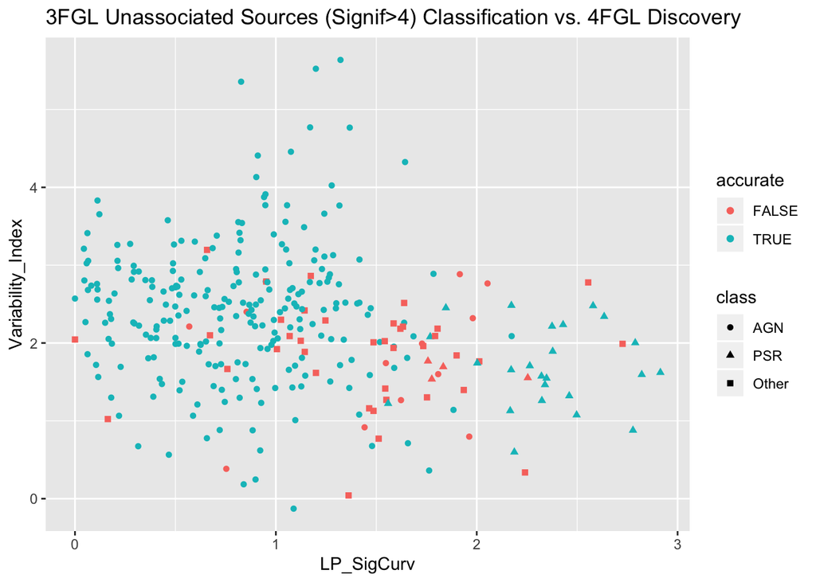

```r
ggplot(FGL3_accuracy_pred_all, aes(x=LP_SigCurv, y=Variability_Index, shape=class, color= accurate)) +
        geom_point() +
        labs(title="3FGL Unassociated Sources (Signif>4) Classification vs. 4FGL Discovery",
             x="LP_SigCurv", y = "Variability_Index")
```

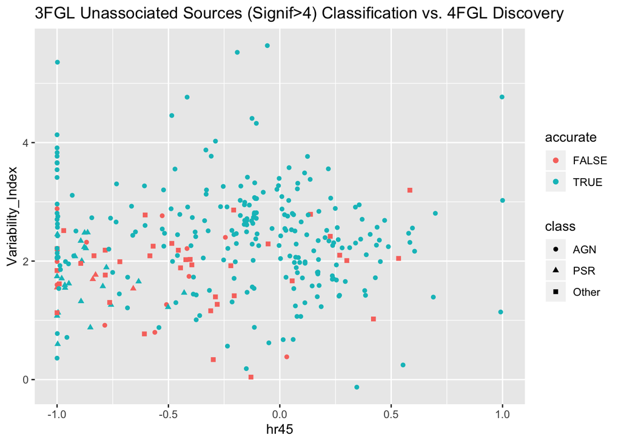

```r
ggplot(FGL3_accuracy_pred_all, aes(x=hr45, y=Variability_Index, shape=class, color= accurate)) +
        geom_point() +
        labs(title="3FGL Unassociated Sources (Signif>4) Classification vs. 4FGL Discovery",
             x="hr45", y = "Variability_Index")
```

### Appendix: Processing 4FGL catalog

```r
sedflux <- function(photon_flux, alpha, Elo, Ehi) {
        R <- Elo/Ehi
        GeV2erg <- 0.00160217657
        (GeV2erg*Elo)*(alpha-1)*(photon_flux)*(R^(alpha/2 - 1))/(1-(R^(alpha-1)))
}

# Subselect small number of variables from those available in 4FGL
FGL4_01 <- select(FGL4,
                  Source_Name, RAJ2000, DEJ2000, GLON, GLAT,
                  PL_Index, LP_Index, PLEC_Index, #Spectral_Index,
                  Variability_Index,
                  Conf_68_SemiMajor, Conf_68_SemiMinor, Conf_68_PosAng,
                  Conf_95_SemiMajor, Conf_95_SemiMinor, Conf_95_PosAng,
                  Signif_Avg,   Pivot_Energy,
                  PL_Flux_Density,     LP_Flux_Density,     PLEC_Flux_Density, #Flux_Density,
                  Unc_PL_Flux_Density, Unc_LP_Flux_Density, Unc_PLEC_Flux_Density, #Unc_Flux_Density,
                  Flux1000, Unc_Flux1000,
                  Energy_Flux100, Unc_Energy_Flux100,
                  LP_SigCurv,     PLEC_SigCurv,  #Signif_Curve,
                  Signif_Avg,
                  Flux_Band.2, #Flux100_300,
                  Flux_Band.3, #Flux300_1000,
                  Flux_Band.4, #Flux1000_3000,
                  Flux_Band.5, #Flux3000_10000,
                  Flux_Band.6, # 10 to 30GeV;   #Flux10000_100000,
                  Flux_Band.7, # 30 to 300 GeV
                  ASSOC_FGL, CLASS1, CLASS2, ASSOC1, ASSOC2) # CLASS2 = agn/unk

# Add new variables (SED points and hardness ratios) computed using sedflux function above
FGL4_02 <- mutate(FGL4_01,
                  SED100_300 = sedflux(Flux_Band.2, PL_Index, 0.1, 0.3),
                  SED300_1000 = sedflux(Flux_Band.3, PL_Index, 0.3, 1.0),
                  SED1000_3000 = sedflux(Flux_Band.4, PL_Index, 1.0, 3.0),
                  SED3000_10000 = sedflux(Flux_Band.5, PL_Index, 3.0, 10.0),
                  SED10000_30000 = sedflux(Flux_Band.6, PL_Index, 10.0, 30.0),
                  SED30000_300000 = sedflux(Flux_Band.7, PL_Index, 10.0, 30.0),
                  #SED100_300 = sedflux(Flux100_300, PL_Index, 0.1, 0.3),
                  #SED300_1000 = sedflux(Flux300_1000, PL_Index, 0.3, 1.0),
                  #SED1000_3000 = sedflux(Flux1000_3000, PL_Index, 1.0, 3.0),
                  #SED3000_10000 = sedflux(Flux3000_10000, PL_Index, 3.0, 10.0),
                  #SED10000_100000 = sedflux(Flux10000_100000, PL_Index, 10.0, 100.0),
                  hr12 = (SED300_1000-SED100_300)/(SED300_1000+SED100_300),
                  hr23 = (SED1000_3000-SED300_1000)/(SED1000_3000+SED300_1000),
                  hr34 = (SED3000_10000-SED1000_3000)/(SED3000_10000+SED1000_3000),
                  hr45 = (SED10000_30000-SED3000_10000)/(SED10000_30000+SED3000_10000),
                  hr56 = (SED30000_300000-SED10000_30000)/(SED30000_300000+SED10000_30000),
                  CLASS1 = gsub(" ", "", CLASS1),
                  CLASS2 = gsub(" ", "", CLASS2))


# Drop highly correlated and some unused variables
FGL4_03 <- select(FGL4_02,
                  -Unc_Flux1000, -Energy_Flux100,
                  -Conf_95_SemiMajor, -Conf_95_SemiMinor,
                  -Conf_68_SemiMajor, -Conf_68_SemiMinor, -Conf_68_PosAng,
                  -Flux1000,
                  -SED100_300, -SED300_1000, -SED1000_3000, -SED3000_10000, #-SED10000_100000,
                  -SED10000_30000, -SED30000_300000,
                  -Flux_Band.2, -Flux_Band.3, -Flux_Band.4, -Flux_Band.5
                  #-Flux100_300, -Flux300_1000, -Flux1000_3000, -Flux3000_10000
                  )

# Take log of variables with highly skewed distributions (removing zeroes to avoid -Inf)
FGL4_04 <- filter(FGL4_03, FGL4_03$LP_SigCurv != 0 | FGL4_03$PLEC_SigCurv != 0) %>%
                mutate(Variability_Index = log(Variability_Index), Pivot_Energy = log(Pivot_Energy),
                PL_Flux_Density = log(PL_Flux_Density),
                LP_Flux_Density = log(LP_Flux_Density),
                PLEC_Flux_Density = log(PLEC_Flux_Density),
                #Flux_Density = log(Flux_Density),
                Unc_PL_Flux_Density = log(Unc_PL_Flux_Density),
                Unc_LP_Flux_Density = log(Unc_LP_Flux_Density),
                Unc_PLEC_Flux_Density = log(Unc_PLEC_Flux_Density),
                #Unc_Flux_Density = log(Unc_Flux_Density),
                Unc_Energy_Flux100 = log(Unc_Energy_Flux100),
                Flux_Band.6 = log (Flux_Band.6),
                Flux_Band.7 = log (Flux_Band.7),
                #Flux10000_100000 = log(Flux10000_100000),
                LP_SigCurv = log(LP_SigCurv + 1), # to prevent -Inf
                PLEC_SigCurv = log(PLEC_SigCurv + 1),
                #Signif_Curve = log(Signif_Curve)
                )

# Drop a few more unused variables
FGL4_05 <- select(FGL4_04, -Pivot_Energy,
                  -Unc_PL_Flux_Density, -Unc_LP_Flux_Density, -Unc_PLEC_Flux_Density,
                  #-Unc_Flux_Density, -Flux10000_100000
                  -Flux_Band.6, -Flux_Band.7)

# Create a tidy data set including "pulsarness" and "agnness" factors
FGL4_tidy <- select(FGL4_05, -RAJ2000, -DEJ2000, -GLON, -Signif_Avg) %>%
                mutate(agnness = factor(CLASS1 == "BCU" | CLASS1 == "bcu"
                                |CLASS1 == "BLL" | CLASS1 == "bll"
                                |CLASS1 == "FSRQ"| CLASS1 == "fsrq"
                                |CLASS1 == "rdg" | CLASS1 == "RDG"
                                |CLASS1 == "nlsy1" | CLASS1 == "NLSY1"
                                |CLASS1 == "agn" | CLASS1 == "ssrq" |CLASS1 == "sey"
                                |CLASS2 == "agn" | CLASS2 == "sey",
                                labels = c("Non-AGN", "AGN")),
               pulsarness = factor(CLASS1 == "PSR" | CLASS1 == "psr" | CLASS2 == "psr",
                                labels = c("Non-Pulsar", "Pulsar")))

FGL4_tidy_for_FGL3 <- select(FGL4_tidy, -GLAT) %>%
        mutate(Source_Name = substr(Source_Name, 6, 18),
               FGL3_Source_name = trimws(substr(ASSOC_FGL,7,18)),
               class = case_when(agnness == "AGN"~"AGN", pulsarness == "Pulsar"~"PSR",
                                 (agnness == "Non-AGN")&(pulsarness =="Non-Pulsar")~"Other"),
               class = factor(class, levels = c("AGN", "PSR","Other"))
               )
```